# Multiple correspondence analysis of BSL questions

Bodo Winter

04/02/2022

## Setup

Load packages:

```r
library(tidyverse)
library(effsize) # for Cohen's d
library(FactoMineR) # for Multiple Correspondence Analysis
library(factoextra) # for interpreting MCA
```

Package versions:

```r
packageVersion('FactoMineR')
```

```
## [1] '2.8'
```

```r
packageVersion('factoextra')
```

```
## [1] '1.0.7'
```

Load helper functions:

```r
source('question_helper_functions.R')
```

Load cleaned data, which is the output from the `preprocessing.Rmd` script:

```r
df <- read_csv('../data/BSL_questions_cleaned.csv')
```

## Exclusions

Following the “turning points” in the `descriptive_statistics.Rmd` file we need to exclude constructed actions as well as “other” and “alternative” questions:

```r
df <- filter(df,
             has_CA == 'no CA',
             semantic %in% c('Content', 'Polar'))
```

## Multiple correspondence analysis

Create a vector that contains all the form variables.

```r
pred_vector <- c('any_head_movement', 'any_head_nod', 'any_head_forward',
                 'any_head_backward', 'any_head_sideward', 'any_head_shake',
                 'any_head_up', 'any_head_down', 'any_eye_brow',
                 'any_eye_brow_up', 'any_eye_brow_down',
                 'any_eye_brow_squint', 'any_eye_brow_wide',
                 'mouthing_question',
                 'manual', 'nonmanual')
```

Create a data frame with all the active variables that will be used in the MCA:

```r
df_active <- df[, pred_vector]
```

Run the MCA:

```r
BSL_MCA <- MCA(df_active, graph = FALSE)
```

Make a scree plot of this:

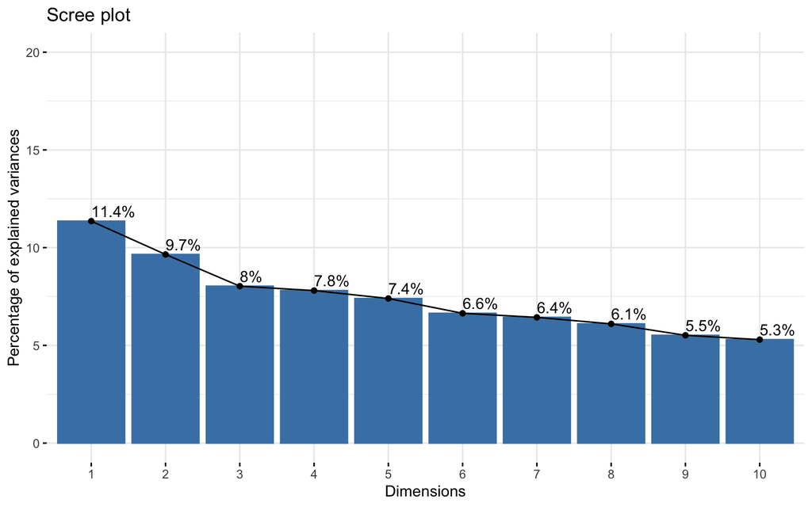

```r
scree_plot <- fviz_screeplot(BSL_MCA, addlabels = TRUE,
                             ylim = c(0, 20))

# Plot & save:

scree_plot
```

```r
ggsave(plot = scree_plot, file = '../figures/MCA_scree_plot.pdf',
       width = 10, height = 6)
```

Correlation between variables and dimensions:

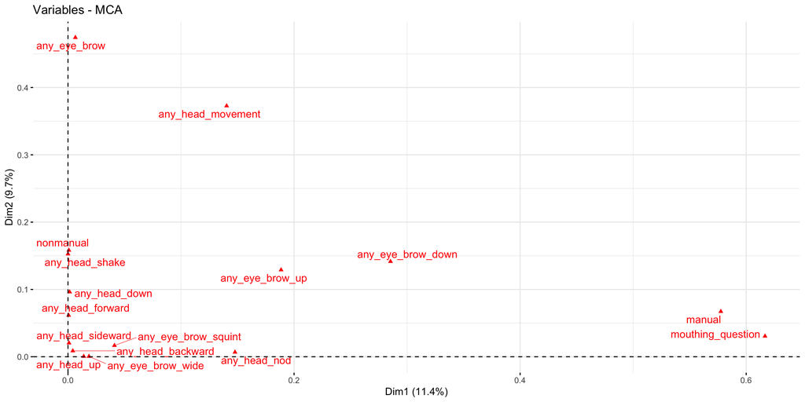

```r
MCA_vars <- fviz_mca_var(BSL_MCA, choice = 'mca.cor',
                         repel = TRUE,
                         ggtheme = theme_minimal())

# Plot & save:

MCA_vars
```

```r
ggsave(plot = MCA_vars, file = '../figures/MCA_vars.pdf',
       width = 10, height = 6)
```

Visualize contributions of the different variables to the first three dimensions:

```r
dim1_contribution <- fviz_contrib(BSL_MCA, choice = 'var', axes = 1, top = 15)
dim2_contribution <- fviz_contrib(BSL_MCA, choice = 'var', axes = 2, top = 15)
dim3_contribution <- fviz_contrib(BSL_MCA, choice = 'var', axes = 3, top = 15)

arrange(dim1_contribution$data, desc(contrib))
```

```
##                                                  name      contrib
## mouthing_question_Single     mouthing_question_Single 2.048397e+01
## manual_Single                           manual_Single 1.499553e+01
## any_eye_brow_down_yes           any_eye_brow_down_yes 9.715189e+00
## manual_Absent                           manual_Absent 8.378675e+00
## mouthing_question_Absent     mouthing_question_Absent 6.400206e+00
## any_eye_brow_up_yes               any_eye_brow_up_yes 5.141631e+00
## any_head_nod_yes                     any_head_nod_yes 4.900482e+00
## manual_Multiple                       manual_Multiple 4.878620e+00
## any_head_movement_no             any_head_movement_no 4.617928e+00
## any_eye_brow_down_no             any_eye_brow_down_no 4.242550e+00
## any_eye_brow_up_no                 any_eye_brow_up_no 4.080133e+00
## mouthing_question_Multiple mouthing_question_Multiple 3.282682e+00
## any_head_nod_no                       any_head_nod_no 2.326754e+00
## any_head_movement_yes           any_head_movement_yes 2.247227e+00
## any_eye_brow_squint_yes       any_eye_brow_squint_yes 1.760431e+00
## any_eye_brow_wide_yes           any_eye_brow_wide_yes 8.750002e-01
## any_head_up_yes                       any_head_up_yes 6.622725e-01
## any_eye_brow_no                       any_eye_brow_no 2.677330e-01
## any_eye_brow_squint_no         any_eye_brow_squint_no 2.494245e-01
## any_head_backward_yes           any_head_backward_yes 2.020314e-01
## any_head_down_yes                   any_head_down_yes 6.742768e-02
## any_eye_brow_yes                     any_eye_brow_yes 5.102407e-02
## any_head_sideward_yes           any_head_sideward_yes 4.067699e-02
## nonmanual_Absent                     nonmanual_Absent 3.745548e-02
## any_eye_brow_wide_no             any_eye_brow_wide_no 3.264926e-02
## any_head_forward_yes             any_head_forward_yes 2.357038e-02
## any_head_up_no                         any_head_up_no 1.962289e-02
## any_head_backward_no             any_head_backward_no 6.759414e-03
## any_head_down_no                     any_head_down_no 4.391841e-03
## any_head_forward_no               any_head_forward_no 3.618690e-03
## any_head_sideward_no             any_head_sideward_no 3.495679e-03
## nonmanual_Present                   nonmanual_Present 8.262238e-04
## any_head_shake_yes                 any_head_shake_yes 1.805013e-05
## any_head_shake_no                   any_head_shake_no 2.389528e-06
```

```r
arrange(dim2_contribution$data, desc(contrib))
```

```
##                                                  name      contrib
## any_eye_brow_no                       any_eye_brow_no 2.292782e+01
## any_head_movement_no             any_head_movement_no 1.442894e+01
## nonmanual_Absent                     nonmanual_Absent 8.909908e+00
## any_head_shake_yes                 any_head_shake_yes 7.761930e+00
## any_head_movement_yes           any_head_movement_yes 7.021571e+00
## any_eye_brow_down_yes           any_eye_brow_down_yes 5.669002e+00
## any_head_down_yes                   any_head_down_yes 5.199719e+00
## any_eye_brow_yes                     any_eye_brow_yes 4.369543e+00
## any_eye_brow_up_yes               any_eye_brow_up_yes 4.140772e+00
## any_eye_brow_up_no                 any_eye_brow_up_no 3.285903e+00
## any_head_forward_yes             any_head_forward_yes 3.073451e+00
## any_eye_brow_down_no             any_eye_brow_down_no 2.475611e+00
## manual_Multiple                       manual_Multiple 1.918171e+00
## mouthing_question_Multiple mouthing_question_Multiple 1.650563e+00
## any_head_sideward_yes           any_head_sideward_yes 1.079986e+00
## any_head_shake_no                   any_head_shake_no 1.027547e+00
## manual_Absent                           manual_Absent 1.012939e+00
## manual_Single                           manual_Single 9.381906e-01
## any_eye_brow_squint_yes       any_eye_brow_squint_yes 8.413266e-01
## any_head_backward_yes           any_head_backward_yes 4.839124e-01
## any_head_forward_no               any_head_forward_no 4.718577e-01
## any_head_down_no                     any_head_down_no 3.386790e-01
## any_head_nod_yes                     any_head_nod_yes 2.630195e-01
## nonmanual_Present                   nonmanual_Present 1.965421e-01
## any_head_nod_no                       any_head_nod_no 1.248819e-01
## any_eye_brow_squint_no         any_eye_brow_squint_no 1.192023e-01
## mouthing_question_Absent     mouthing_question_Absent 9.555596e-02
## any_head_sideward_no             any_head_sideward_no 9.281134e-02
## any_head_up_yes                       any_head_up_yes 2.701382e-02
## any_eye_brow_wide_yes           any_eye_brow_wide_yes 2.531082e-02
## any_head_backward_no             any_head_backward_no 1.619038e-02
## mouthing_question_Single     mouthing_question_Single 1.037809e-02
## any_eye_brow_wide_no             any_eye_brow_wide_no 9.444336e-04
## any_head_up_no                         any_head_up_no 8.004095e-04
```

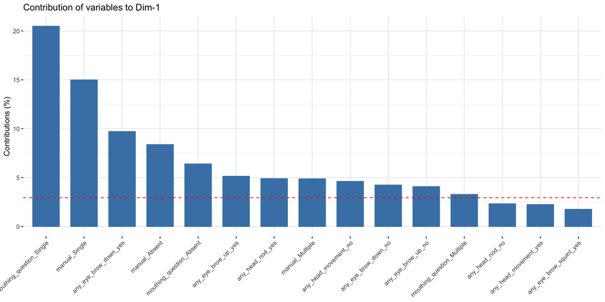

```r
# Plot & save:

dim1_contribution
```

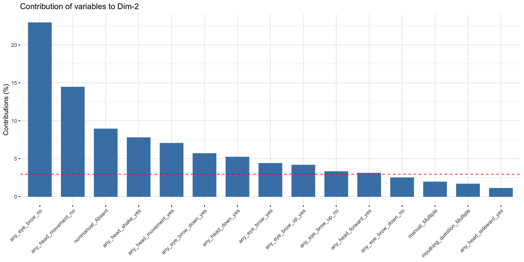

```r
dim2_contribution
```

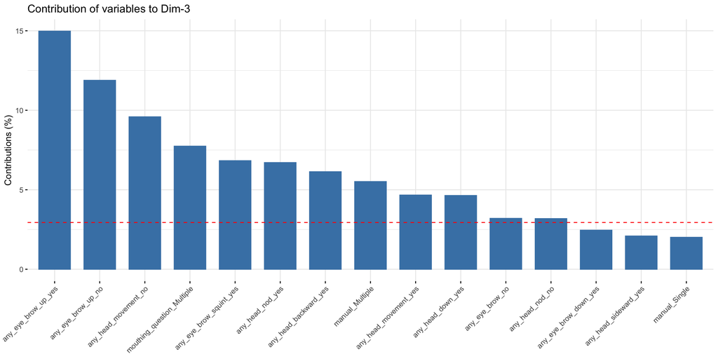

```r
dim3_contribution
```

```r
ggsave(plot = dim1_contribution, file = '../figures/pdf/MCA_dim1_contributions.pdf',
       width = 10, height = 6)
ggsave(plot = dim2_contribution, file = '../figures/pdf/MCA_dim2_contributions.pdf',
       width = 10, height = 6)
ggsave(plot = dim3_contribution, file = '../figures/pdf/MCA_dim3_contributions.pdf',
       width = 10, height = 6)
ggsave(plot = dim1_contribution, file = '../figures/png/MCA_dim1_contributions.png',
       width = 10, height = 6)
ggsave(plot = dim2_contribution, file = '../figures/png/MCA_dim2_contributions.png',
       width = 10, height = 6)
ggsave(plot = dim3_contribution, file = '../figures/png/MCA_dim3_contributions.png',
       width = 10, height = 6)
```

The first one is clearly: mouthing + manuals, which go together….

Let’s look at the precise values:

```r
BSL_MCA_var <- get_mca_var(BSL_MCA)

round(BSL_MCA_var$contrib, 2)
```

```
##                            Dim 1 Dim 2 Dim 3 Dim 4 Dim 5
## any_head_movement_no        4.62 14.43  9.59  0.07  7.29
## any_head_movement_yes       2.25  7.02  4.67  0.03  3.55
## any_head_nod_no             2.33  0.12  3.19  2.05  7.07
## any_head_nod_yes            4.90  0.26  6.71  4.31 14.89
## any_head_forward_no         0.00  0.47  0.07  0.35  0.04
## any_head_forward_yes        0.02  3.07  0.46  2.31  0.28
## any_head_backward_no        0.01  0.02  0.21  0.35  0.06
## any_head_backward_yes       0.20  0.48  6.13 10.51  1.83
## any_head_sideward_no        0.00  0.09  0.18  1.26  0.01
## any_head_sideward_yes       0.04  1.08  2.09 14.61  0.12
## any_head_shake_no           0.00  1.03  0.03  0.37  0.00
## any_head_shake_yes          0.00  7.76  0.24  2.77  0.00
## any_head_up_no              0.02  0.00  0.04  0.00  0.08
## any_head_up_yes             0.66  0.03  1.38  0.13  2.77
## any_head_down_no            0.00  0.34  0.30  0.25  0.05
## any_head_down_yes           0.07  5.20  4.64  3.85  0.74
## any_eye_brow_no             0.27 22.93  3.20  4.37  5.26
## any_eye_brow_yes            0.05  4.37  0.61  0.83  1.00
## any_eye_brow_up_no          4.08  3.29 11.88  0.61  0.15
## any_eye_brow_up_yes         5.14  4.14 14.97  0.77  0.19
## any_eye_brow_down_no        4.24  2.48  1.07  0.63  0.16
## any_eye_brow_down_yes       9.72  5.67  2.46  1.44  0.37
## any_eye_brow_squint_no      0.25  0.12  0.97  1.52  1.73
## any_eye_brow_squint_yes     1.76  0.84  6.83 10.72 12.23
## any_eye_brow_wide_no        0.03  0.00  0.00  0.02  0.04
## any_eye_brow_wide_yes       0.88  0.03  0.00  0.54  1.06
## mouthing_question_Absent    6.40  0.10  0.01  0.07  0.08
## mouthing_question_Multiple  3.28  1.65  7.74 13.92 14.70
## mouthing_question_Single   20.48  0.01  0.99  1.07  4.88
## manual_Absent               8.38  1.01  0.00  0.56  0.21
## manual_Multiple             4.88  1.92  5.51 16.51 10.62
## manual_Single              15.00  0.94  2.01  1.30  8.02
## nonmanual_Absent            0.04  8.91  1.77  1.87  0.51
## nonmanual_Present           0.00  0.20  0.04  0.04  0.01
```

Double-check that these are actually percentages out of the definition of the dimension:

```r
colSums(BSL_MCA_var$contrib)
```

```
## Dim 1 Dim 2 Dim 3 Dim 4 Dim 5
##   100   100   100   100   100
```

Yes they are, column-wise things add up to 100%.

Extract individuals:

```r
MCA_inds <- get_mca_ind(BSL_MCA)

# Extract coordinates:

inds_coords <- as_tibble(MCA_inds$coord) %>%
  rename(Dim1 = `Dim 1`,
         Dim2 = `Dim 2`,
         Dim3 = `Dim 3`,
         Dim4 = `Dim 4`,
         Dim5 = `Dim 5`)

# Append semantic type labels:

inds_coords <- bind_cols(inds_coords,
                         select(df, semantic, question, social_action))

# Check:

inds_coords
```

```
## # A tibble: 556 × 8
##       Dim1    Dim2    Dim3    Dim4     Dim5 semantic question      social_action
##      <dbl>   <dbl>   <dbl>   <dbl>    <dbl> <chr>    <chr>         <chr>
##  1 -0.0173  0.394  -0.554   0.194  -0.0113  Content  Continuing    request info…
##  2 -0.133   0.182  -0.153   0.117  -0.354   Content  Initiating    request info…
##  3  0.561   0.215   0.153  -0.0738 -0.562   Content  Initiating-NR OIR-restrict…
##  4  0.0469 -0.674  -0.0530  0.101   0.0377  Content  Continuing-NR OIR-restrict…
##  5  0.150  -0.0982 -0.523  -0.0346  0.0716  Polar    Continuing    OIR-restrict…
##  6 -0.0177  0.625  -0.513   0.331  -0.0112  Polar    Initiating    OIR-restrict…
##  7 -0.272   0.205  -0.192  -0.0988  0.0207  Polar    Initiating    OIR-restrict…
##  8  0.379   0.305   0.0950 -0.275  -0.215   Polar    Continuing    request conf…
##  9  0.321   0.409  -0.610   0.140  -0.149   Content  Initiating    request info…
## 10  0.525  -0.0298  0.339   0.581  -0.00297 Content  Initiating    request info…
## # ℹ 546 more rows
```

Make a plot of the individuals. If you swap “Q_semantic” with “Question” or “Q_social_action” you can get graphs for that.

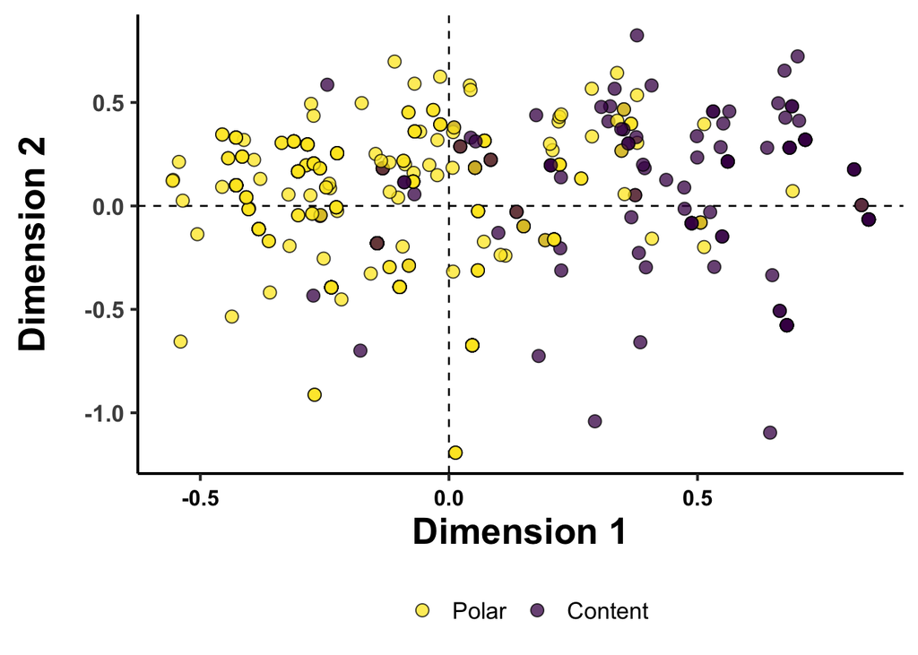

```r
# Plot basics:

coord_p <- inds_coords %>%
  ggplot(aes(x = Dim1, y = Dim2, fill = semantic))

# Geoms:

coord_p <- coord_p +
  geom_vline(aes(xintercept = 0), linetype = 2) +
  geom_hline(aes(yintercept = 0), linetype = 2) +
  geom_point(size = 3, alpha = 0.75, col = 'black', pch = 21)

# Scales and axes:

coord_p <- coord_p +
  xlab('Dimension 1') +
  ylab('Dimension 2') +
  scale_fill_viridis_d(guide = guide_legend(reverse = TRUE)) +
  theme_BSL() +
  theme(legend.position = 'bottom',
        legend.title = element_blank(),
        axis.text.y = element_text(face = 'bold'))

# Plot & save:

coord_p
```

```r
ggsave(plot = coord_p, file = '../figures/pdf/MCA_2D_solution_tokens.pdf',
       width = 8, height = 6)
ggsave(plot = coord_p, file = '../figures/png/MCA_2D_solution_tokens.png',
       width = 8, height = 6)
```

Check the dimension description:

```r
MCA_description <- dimdesc(BSL_MCA, axes = c(1, 2))

# Check them:

MCA_description[[1]]
```

```
##
## Link between the variable and the categorical variable (1-way anova)
## =============================================
##                             R2       p.value
## mouthing_question   0.61666714 7.223981e-116
## manual              0.57754075 3.384572e-104
## any_eye_brow_down   0.28532239  2.448526e-42
## any_eye_brow_up     0.18851016  5.760195e-27
## any_head_nod        0.14773826  5.123490e-21
## any_head_movement   0.14033667  5.763827e-20
## any_eye_brow_squint 0.04108522  1.444038e-06
## any_eye_brow_wide   0.01855406  1.283464e-03
## any_head_up         0.01393922  5.313139e-03
##
## Link between variable and the categories of the categorical variables
## ================================================================
##                                                Estimate       p.value
## mouthing_question=mouthing_question_Single    0.2406111  5.278970e-88
## manual=manual_Single                          0.2105289  1.231884e-61
## any_eye_brow_down=any_eye_brow_down_yes       0.2075460  2.448526e-42
## any_eye_brow_up=any_eye_brow_up_no            0.1562299  5.760195e-27
## any_head_nod=any_head_nod_no                  0.1470261  5.123490e-21
## any_head_movement=any_head_movement_no        0.1426787  5.763827e-20
## manual=manual_Multiple                        0.1813211  1.542605e-15
## mouthing_question=mouthing_question_Multiple  0.2098313  2.840986e-10
## any_eye_brow_squint=any_eye_brow_squint_no    0.1098750  1.444038e-06
## any_eye_brow_wide=any_eye_brow_wide_no        0.1307276  1.283464e-03
## any_head_up=any_head_up_no                    0.1262140  5.313139e-03
## any_head_up=any_head_up_yes                  -0.1262140  5.313139e-03
## any_eye_brow_wide=any_eye_brow_wide_yes      -0.1307276  1.283464e-03
## any_eye_brow_squint=any_eye_brow_squint_yes  -0.1098750  1.444038e-06
## any_head_movement=any_head_movement_yes      -0.1426787  5.763827e-20
## any_head_nod=any_head_nod_yes                -0.1470261  5.123490e-21
## any_eye_brow_up=any_eye_brow_up_yes          -0.1562299  5.760195e-27
## any_eye_brow_down=any_eye_brow_down_no       -0.2075460  2.448526e-42
## manual=manual_Absent                         -0.3918499 1.267769e-105
## mouthing_question=mouthing_question_Absent   -0.4504424 2.233287e-117
```

```r
MCA_description[[2]]
```

```
##
## Link between the variable and the categorical variable (1-way anova)
## =============================================
##                              R2      p.value
## any_eye_brow        0.474266508 2.203941e-79
## any_head_movement   0.372682823 4.435710e-58
## nonmanual           0.158216155 1.610146e-22
## any_head_shake      0.152709025 9.973567e-22
## any_eye_brow_down   0.141505118 3.938513e-20
## any_eye_brow_up     0.129031609 2.239661e-18
## any_head_down       0.096224544 7.245458e-14
## any_head_forward    0.061596462 2.991993e-09
## manual              0.067225520 4.397900e-09
## mouthing_question   0.030517506 1.898026e-04
## any_head_sideward   0.020376277 7.365071e-04
## any_eye_brow_squint 0.016688302 2.272936e-03
## any_head_backward   0.008688824 2.796402e-02
##
## Link between variable and the categories of the categorical variables
## ================================================================
##                                                  Estimate      p.value
## any_eye_brow=any_eye_brow_yes                 0.309452101 2.203941e-79
## any_head_movement=any_head_movement_yes       0.214355112 4.435710e-58
## nonmanual=nonmanual_Present                   0.450994236 1.610146e-22
## any_head_shake=any_head_shake_yes             0.200387478 9.973567e-22
## any_eye_brow_down=any_eye_brow_down_yes       0.134748175 3.938513e-20
## any_eye_brow_up=any_eye_brow_up_yes           0.119161321 2.239661e-18
## any_head_down=any_head_down_yes               0.213306394 7.245458e-14
## any_head_forward=any_head_forward_yes         0.120385494 2.991993e-09
## manual=manual_Multiple                        0.128159468 6.141442e-06
## mouthing_question=mouthing_question_Multiple  0.208325160 4.490747e-05
## manual=manual_Single                          0.007264699 6.501514e-04
## any_head_sideward=any_head_sideward_yes       0.087123789 7.365071e-04
## any_eye_brow_squint=any_eye_brow_squint_no    0.064558391 2.272936e-03
## any_head_backward=any_head_backward_yes       0.086773829 2.796402e-02
## mouthing_question=mouthing_question_Absent   -0.116943239 3.707749e-02
## any_head_backward=any_head_backward_no       -0.086773829 2.796402e-02
## any_eye_brow_squint=any_eye_brow_squint_yes  -0.064558391 2.272936e-03
## any_head_sideward=any_head_sideward_no       -0.087123789 7.365071e-04
## manual=manual_Absent                         -0.135424168 5.990081e-09
## any_head_forward=any_head_forward_no         -0.120385494 2.991993e-09
## any_head_down=any_head_down_no               -0.213306394 7.245458e-14
## any_eye_brow_up=any_eye_brow_up_no           -0.119161321 2.239661e-18
## any_eye_brow_down=any_eye_brow_down_no       -0.134748175 3.938513e-20
## any_head_shake=any_head_shake_no             -0.200387478 9.973567e-22
## nonmanual=nonmanual_Absent                   -0.450994236 1.610146e-22
## any_head_movement=any_head_movement_no       -0.214355112 4.435710e-58
## any_eye_brow=any_eye_brow_no                 -0.309452101 2.203941e-79
```

Reinforces the view that the first dimension is for manual + mouthing and the second is eyes & eye brows plus head.

Check which ones of the five dimensions differentiate `semantic` (content/polar questions):

```r
inds_coords |>
  group_by(semantic) |>
  summarize(M_dim1 = mean(Dim1),
            M_dim2 = mean(Dim2),
            M_dim3 = mean(Dim3),
            M_dim4 = mean(Dim4),
            M_dim5 = mean(Dim5))
```

```
## # A tibble: 2 × 6
##   semantic M_dim1  M_dim2   M_dim3  M_dim4   M_dim5
##   <chr>     <dbl>   <dbl>    <dbl>   <dbl>    <dbl>
## 1 Content   0.412  0.0425  0.0165   0.0398 -0.0122
## 2 Polar    -0.139 -0.0143 -0.00554 -0.0134  0.00412
```

See the effect sizes for this:

```r
with(inds_coords, cohen.d(Dim1 ~ semantic))
```

```
##
## Cohen's d
##
## d estimate: 2.069023 (large)
## 95 percent confidence interval:
##    lower    upper
## 1.841675 2.296372
```

```r
with(inds_coords, cohen.d(Dim2 ~ semantic))
```

```
##
## Cohen's d
##
## d estimate: 0.1724951 (negligible)
## 95 percent confidence interval:
##      lower      upper
## -0.0196956  0.3646858
```

```r
with(inds_coords, cohen.d(Dim3 ~ semantic))
```

```
##
## Cohen's d
##
## d estimate: 0.07317027 (negligible)
## 95 percent confidence interval:
##      lower      upper
## -0.1188001  0.2651406
```

```r
with(inds_coords, cohen.d(Dim4 ~ semantic))
```

```
##
## Cohen's d
##
## d estimate: 0.1795788 (negligible)
## 95 percent confidence interval:
##       lower       upper
## -0.01263441  0.37179205
```

```r
with(inds_coords, cohen.d(Dim5 ~ semantic))
```

```
##
## Cohen's d
##
## d estimate: -0.05661008 (negligible)
## 95 percent confidence interval:
##      lower      upper
## -0.2485610  0.1353408
```

Ok, so the other dimensions really don’t differentiate between polar and content questions. It’s only Dimension 1.